# Machine Learning about Weight Lifting

Tyler Byers

Coursera Practical Machine Learning

Sept 2014

The goal of this project is to use body sensor data to predict the manner in which various subjects completed a set of repetitions of a Biceps curl with a light weight. More information can be found at the original data source: http://groupware.les.inf.puc-rio.br/har

## Load and Initially Process Data

```r
library(caret); library(ggplot2)
train <- read.csv('pml-training.csv')
test <- read.csv('pml-testing.csv')
```

Summarize the data.

```r
summary(train)
```

```
##        X            user_name    raw_timestamp_part_1 raw_timestamp_part_2
##  Min.   :    1   adelmo  :3892   Min.   :1.32e+09     Min.   :   294
##  1st Qu.: 4906   carlitos:3112   1st Qu.:1.32e+09     1st Qu.:252912
##  Median : 9812   charles :3536   Median :1.32e+09     Median :496380
##  Mean   : 9812   eurico  :3070   Mean   :1.32e+09     Mean   :500656
##  3rd Qu.:14717   jeremy  :3402   3rd Qu.:1.32e+09     3rd Qu.:751891
##  Max.   :19622   pedro   :2610   Max.   :1.32e+09     Max.   :998801
##
##           cvtd_timestamp  new_window    num_window    roll_belt
##  28/11/2011 14:14: 1498   no :19216   Min.   :  1   Min.   :-28.9
##  05/12/2011 11:24: 1497   yes:  406   1st Qu.:222   1st Qu.:  1.1
##  30/11/2011 17:11: 1440               Median :424   Median :113.0
##  05/12/2011 11:25: 1425               Mean   :431   Mean   : 64.4
##  02/12/2011 14:57: 1380               3rd Qu.:644   3rd Qu.:123.0
##  02/12/2011 13:34: 1375               Max.   :864   Max.   :162.0
##  (Other)         :11007
##    pitch_belt        yaw_belt      total_accel_belt kurtosis_roll_belt
##  Min.   :-55.80   Min.   :-180.0   Min.   : 0.0              :19216
##  1st Qu.:  1.76   1st Qu.: -88.3   1st Qu.: 3.0     #DIV/0!  :   10
##  Median :  5.28   Median : -13.0   Median :17.0     -1.908453:    2
##  Mean   :  0.31   Mean   : -11.2   Mean   :11.3     -0.016850:    1
##  3rd Qu.: 14.90   3rd Qu.:  12.9   3rd Qu.:18.0     -0.021024:    1
##  Max.   : 60.30   Max.   : 179.0   Max.   :29.0     -0.025513:    1
##                                                     (Other)  :  391
##  kurtosis_picth_belt kurtosis_yaw_belt skewness_roll_belt
##           :19216            :19216              :19216
##  #DIV/0!  :   32     #DIV/0!:  406     #DIV/0!  :    9
##  47.000000:    4                       0.000000 :    4
##  -0.150950:    3                       0.422463 :    2
##  -0.684748:    3                       -0.003095:    1
##  -1.750749:    3                       -0.010002:    1
##  (Other)  :  361                       (Other)  :  389
##  skewness_roll_belt.1 skewness_yaw_belt max_roll_belt   max_picth_belt
##           :19216             :19216     Min.   :-94     Min.   : 3
##  #DIV/0!  :   32      #DIV/0!:  406     1st Qu.:-88     1st Qu.: 5
##  0.000000 :    4                        Median : -5     Median :18
##  -2.156553:    3                        Mean   : -7     Mean   :13
##  -3.072669:    3                        3rd Qu.: 18     3rd Qu.:19
##  -6.324555:    3                        Max.   :180     Max.   :30
##  (Other)  :  361                        NA's   :19216   NA's   :19216
```

[output cut: 289 more lines]

```
##  Min.   : -8.09   Min.   :-498.0   Min.   :-632    Min.   :-446.0
##  1st Qu.: -0.18   1st Qu.:-178.0   1st Qu.:  57    1st Qu.:-182.0
##  Median :  0.08   Median : -57.0   Median : 201    Median : -39.0
##  Mean   :  0.15   Mean   : -61.7   Mean   : 164    Mean   : -55.3
##  3rd Qu.:  0.49   3rd Qu.:  76.0   3rd Qu.: 312    3rd Qu.:  26.0
##  Max.   :231.00   Max.   : 477.0   Max.   : 923    Max.   : 291.0
##
##  magnet_forearm_x magnet_forearm_y magnet_forearm_z classe
##  Min.   :-1280    Min.   :-896     Min.   :-973     A:5580
##  1st Qu.: -616    1st Qu.:   2     1st Qu.: 191     B:3797
##  Median : -378    Median : 591     Median : 511     C:3422
##  Mean   : -313    Mean   : 380     Mean   : 394     D:3216
##  3rd Qu.:  -73    3rd Qu.: 737     3rd Qu.: 653     E:3607
##  Max.   :  672    Max.   :1480     Max.   :1090
##
```

```r
names(train)
```

```
##   [1] "X"                        "user_name"
##   [3] "raw_timestamp_part_1"     "raw_timestamp_part_2"
##   [5] "cvtd_timestamp"           "new_window"
##   [7] "num_window"               "roll_belt"
##   [9] "pitch_belt"               "yaw_belt"
##  [11] "total_accel_belt"         "kurtosis_roll_belt"
##  [13] "kurtosis_picth_belt"      "kurtosis_yaw_belt"
##  [15] "skewness_roll_belt"       "skewness_roll_belt.1"
##  [17] "skewness_yaw_belt"        "max_roll_belt"
##  [19] "max_picth_belt"           "max_yaw_belt"
##  [21] "min_roll_belt"            "min_pitch_belt"
##  [23] "min_yaw_belt"             "amplitude_roll_belt"
##  [25] "amplitude_pitch_belt"     "amplitude_yaw_belt"
##  [27] "var_total_accel_belt"     "avg_roll_belt"
##  [29] "stddev_roll_belt"         "var_roll_belt"
```

[output cut: 65 more lines]

There are a lot of variables that have NA in them. Most of these variables have 19216 NAs, out of 19622 observations. This is so many NAs as to make these variables useless. Also, there are several variables with thousands of blank entries along with '#DIV/0!' entries. These also should be thrown out. We will also remove variables such as `X` and the timestamps. Also, a later evaluation of the test set revealed that the `new_window` variable only had `no` so we will remove that variable as a predictor as well. The following code removes these variables from both the train and test set.

```r
# keep the below columns
keepvars <- c(2,7:11,37:49,60:68,84:86,102,113:124,140,151:160)
train <- train[,keepvars]
test <- test[,keepvars]
# Ensure we're left with usable variables
summary(train)
```

```
##     user_name      num_window    roll_belt       pitch_belt
##  adelmo  :3892   Min.   :  1   Min.   :-28.9   Min.   :-55.80
##  carlitos:3112   1st Qu.:222   1st Qu.:  1.1   1st Qu.:  1.76
##  charles :3536   Median :424   Median :113.0   Median :  5.28
##  eurico  :3070   Mean   :431   Mean   : 64.4   Mean   :  0.31
##  jeremy  :3402   3rd Qu.:644   3rd Qu.:123.0   3rd Qu.: 14.90
##  pedro   :2610   Max.   :864   Max.   :162.0   Max.   : 60.30
##     yaw_belt      total_accel_belt  gyros_belt_x      gyros_belt_y
##  Min.   :-180.0   Min.   : 0.0     Min.   :-1.0400   Min.   :-0.6400
##  1st Qu.: -88.3   1st Qu.: 3.0     1st Qu.:-0.0300   1st Qu.: 0.0000
##  Median : -13.0   Median :17.0     Median : 0.0300   Median : 0.0200
##  Mean   : -11.2   Mean   :11.3     Mean   :-0.0056   Mean   : 0.0396
##  3rd Qu.:  12.9   3rd Qu.:18.0     3rd Qu.: 0.1100   3rd Qu.: 0.1100
##  Max.   : 179.0   Max.   :29.0     Max.   : 2.2200   Max.   : 0.6400
##   gyros_belt_z     accel_belt_x      accel_belt_y    accel_belt_z
##  Min.   :-1.460   Min.   :-120.00   Min.   :-69.0   Min.   :-275.0
##  1st Qu.:-0.200   1st Qu.: -21.00   1st Qu.:  3.0   1st Qu.:-162.0
##  Median :-0.100   Median : -15.00   Median : 35.0   Median :-152.0
##  Mean   :-0.131   Mean   :  -5.59   Mean   : 30.1   Mean   : -72.6
##  3rd Qu.:-0.020   3rd Qu.:  -5.00   3rd Qu.: 61.0   3rd Qu.:  27.0
##  Max.   : 1.620   Max.   :  85.00   Max.   :164.0   Max.   : 105.0
##  magnet_belt_x   magnet_belt_y magnet_belt_z     roll_arm
##  Min.   :-52.0   Min.   :354   Min.   :-623   Min.   :-180.0
##  1st Qu.:  9.0   1st Qu.:581   1st Qu.:-375   1st Qu.: -31.8
##  Median : 35.0   Median :601   Median :-320   Median :   0.0
##  Mean   : 55.6   Mean   :594   Mean   :-346   Mean   :  17.8
##  3rd Qu.: 59.0   3rd Qu.:610   3rd Qu.:-306   3rd Qu.:  77.3
##  Max.   :485.0   Max.   :673   Max.   : 293   Max.   : 180.0
##    pitch_arm         yaw_arm        total_accel_arm  gyros_arm_x
##  Min.   :-88.80   Min.   :-180.00   Min.   : 1.0    Min.   :-6.370
##  1st Qu.:-25.90   1st Qu.: -43.10   1st Qu.:17.0    1st Qu.:-1.330
##  Median :  0.00   Median :   0.00   Median :27.0    Median : 0.080
##  Mean   : -4.61   Mean   :  -0.62   Mean   :25.5    Mean   : 0.043
##  3rd Qu.: 11.20   3rd Qu.:  45.88   3rd Qu.:33.0    3rd Qu.: 1.570
##  Max.   : 88.50   Max.   : 180.00   Max.   :66.0    Max.   : 4.870
##   gyros_arm_y      gyros_arm_z     accel_arm_x      accel_arm_y
##  Min.   :-3.440   Min.   :-2.33   Min.   :-404.0   Min.   :-318.0
##  1st Qu.:-0.800   1st Qu.:-0.07   1st Qu.:-242.0   1st Qu.: -54.0
##  Median :-0.240   Median : 0.23   Median : -44.0   Median :  14.0
##  Mean   :-0.257   Mean   : 0.27   Mean   : -60.2   Mean   :  32.6
```

[output cut: 43 more lines]

```
##  Max.   :108.0       Max.   :  3.970   Max.   :311.00   Max.   :231.00
##  accel_forearm_x  accel_forearm_y accel_forearm_z  magnet_forearm_x
##  Min.   :-498.0   Min.   :-632    Min.   :-446.0   Min.   :-1280
##  1st Qu.:-178.0   1st Qu.:  57    1st Qu.:-182.0   1st Qu.: -616
##  Median : -57.0   Median : 201    Median : -39.0   Median : -378
##  Mean   : -61.7   Mean   : 164    Mean   : -55.3   Mean   : -313
##  3rd Qu.:  76.0   3rd Qu.: 312    3rd Qu.:  26.0   3rd Qu.:  -73
##  Max.   : 477.0   Max.   : 923    Max.   : 291.0   Max.   :  672
##  magnet_forearm_y magnet_forearm_z classe
##  Min.   :-896     Min.   :-973     A:5580
##  1st Qu.:   2     1st Qu.: 191     B:3797
##  Median : 591     Median : 511     C:3422
##  Mean   : 380     Mean   : 394     D:3216
##  3rd Qu.: 737     3rd Qu.: 653     E:3607
##  Max.   :1480     Max.   :1090
```

```r
summary(test)
```

```
##     user_name   num_window    roll_belt        pitch_belt
##  adelmo  :1   Min.   : 48   Min.   : -5.92   Min.   :-41.60
##  carlitos:3   1st Qu.:250   1st Qu.:  0.91   1st Qu.:  3.01
##  charles :1   Median :384   Median :  1.11   Median :  4.66
##  eurico  :4   Mean   :380   Mean   : 31.31   Mean   :  5.82
##  jeremy  :8   3rd Qu.:467   3rd Qu.: 32.51   3rd Qu.:  6.13
##  pedro   :3   Max.   :859   Max.   :129.00   Max.   : 27.80
##     yaw_belt     total_accel_belt  gyros_belt_x     gyros_belt_y
##  Min.   :-93.7   Min.   : 2.00    Min.   :-0.500   Min.   :-0.050
##  1st Qu.:-88.6   1st Qu.: 3.00    1st Qu.:-0.070   1st Qu.:-0.005
##  Median :-87.8   Median : 4.00    Median : 0.020   Median : 0.000
##  Mean   :-59.3   Mean   : 7.55    Mean   :-0.045   Mean   : 0.010
##  3rd Qu.:-63.5   3rd Qu.: 8.00    3rd Qu.: 0.070   3rd Qu.: 0.020
##  Max.   :162.0   Max.   :21.00    Max.   : 0.240   Max.   : 0.110
##   gyros_belt_z     accel_belt_x     accel_belt_y    accel_belt_z
##  Min.   :-0.480   Min.   :-48.00   Min.   :-16.0   Min.   :-187.0
##  1st Qu.:-0.138   1st Qu.:-19.00   1st Qu.:  2.0   1st Qu.: -24.0
##  Median :-0.025   Median :-13.00   Median :  4.5   Median :  27.0
##  Mean   :-0.101   Mean   :-13.50   Mean   : 18.4   Mean   : -17.6
##  3rd Qu.: 0.000   3rd Qu.: -8.75   3rd Qu.: 25.5   3rd Qu.:  38.2
##  Max.   : 0.050   Max.   : 46.00   Max.   : 72.0   Max.   :  49.0
##  magnet_belt_x   magnet_belt_y magnet_belt_z     roll_arm
##  Min.   :-13.0   Min.   :566   Min.   :-426   Min.   :-137.0
##  1st Qu.:  5.5   1st Qu.:578   1st Qu.:-398   1st Qu.:   0.0
##  Median : 33.5   Median :600   Median :-314   Median :   0.0
##  Mean   : 35.1   Mean   :602   Mean   :-347   Mean   :  16.4
##  3rd Qu.: 46.2   3rd Qu.:631   3rd Qu.:-305   3rd Qu.:  71.5
##  Max.   :169.0   Max.   :638   Max.   :-291   Max.   : 152.0
##    pitch_arm         yaw_arm       total_accel_arm  gyros_arm_x
##  Min.   :-63.80   Min.   :-167.0   Min.   : 3.0    Min.   :-3.710
##  1st Qu.: -9.19   1st Qu.: -60.1   1st Qu.:20.2    1st Qu.:-0.645
##  Median :  0.00   Median :   0.0   Median :29.5    Median : 0.020
##  Mean   : -3.95   Mean   :  -2.8   Mean   :26.4    Mean   : 0.077
##  3rd Qu.:  3.46   3rd Qu.:  25.5   3rd Qu.:33.2    3rd Qu.: 1.248
##  Max.   : 55.00   Max.   : 178.0   Max.   :44.0    Max.   : 3.660
##   gyros_arm_y      gyros_arm_z      accel_arm_x      accel_arm_y
##  Min.   :-2.090   Min.   :-0.690   Min.   :-341.0   Min.   :-65.0
##  1st Qu.:-0.635   1st Qu.:-0.180   1st Qu.:-277.0   1st Qu.: 52.2
##  Median :-0.040   Median :-0.025   Median :-194.5   Median :112.0
##  Mean   :-0.160   Mean   : 0.120   Mean   :-134.6   Mean   :103.1
```

[output cut: 43 more lines]

```
##  Max.   :47.0        Max.   : 1.380   Max.   : 4.260   Max.   : 1.8000
##  accel_forearm_x  accel_forearm_y  accel_forearm_z  magnet_forearm_x
##  Min.   :-212.0   Min.   :-331.0   Min.   :-282.0   Min.   :-714.0
##  1st Qu.:-114.8   1st Qu.:   8.5   1st Qu.:-199.0   1st Qu.:-427.2
##  Median :  86.0   Median : 138.0   Median :-148.5   Median :-189.5
##  Mean   :  38.8   Mean   : 125.3   Mean   : -93.7   Mean   :-159.2
##  3rd Qu.: 166.2   3rd Qu.: 268.0   3rd Qu.: -31.0   3rd Qu.:  41.5
##  Max.   : 232.0   Max.   : 406.0   Max.   : 179.0   Max.   : 532.0
##  magnet_forearm_y magnet_forearm_z   problem_id
##  Min.   :-787     Min.   :-32      Min.   : 1.00
##  1st Qu.:-329     1st Qu.:275      1st Qu.: 5.75
##  Median : 487     Median :492      Median :10.50
##  Mean   : 192     Mean   :460      Mean   :10.50
##  3rd Qu.: 721     3rd Qu.:662      3rd Qu.:15.25
##  Max.   : 800     Max.   :884      Max.   :20.00
```

Now we have a much more manageable data set with only 54 predictors instead of 159 predictors.

## Split Data

Now we split the train set into a further training and testing set, which we will call `mytrain` and `mytest`.

```r
set.seed(919)
trainIndex <- createDataPartition(train$classe, p = 0.75, list = FALSE)
mytrain <- train[trainIndex,]
mytest <- train[-trainIndex,]
```

## Decision Tree Model

As an admittedly lazy first step, we will see how a decision tree model works using all the predictor variables.

```r
library(rattle); library(rpart.plot)
rpmod <- train(classe ~ ., method = 'rpart', data = mytrain)
rpmod$finalModel
```

```
## n= 14718
##
## node), split, n, loss, yval, (yprob)
##       * denotes terminal node
##
##  1) root 14718 10530 A (0.28 0.19 0.17 0.16 0.18)
##    2) roll_belt< 130.5 13492  9316 A (0.31 0.21 0.19 0.18 0.11)
##      4) pitch_forearm< -33.95 1158     3 A (1 0.0026 0 0 0) *
##      5) pitch_forearm>=-33.95 12334  9313 A (0.24 0.23 0.21 0.2 0.12)
##       10) num_window>=45.5 11797  8776 A (0.26 0.24 0.22 0.2 0.09)
##         20) num_window< 241.5 2694  1252 A (0.54 0.12 0.1 0.19 0.052) *
##         21) num_window>=241.5 9103  6585 B (0.17 0.28 0.25 0.2 0.1)
##           42) magnet_dumbbell_z< -24.5 2563  1358 A (0.47 0.34 0.047 0.13 0.013)
##             84) num_window< 686.5 1269   269 A (0.79 0.17 0.0032 0.033 0.01) *
##             85) num_window>=686.5 1294   621 B (0.16 0.52 0.09 0.22 0.015) *
##           43) magnet_dumbbell_z>=-24.5 6540  4372 C (0.057 0.25 0.33 0.23 0.14)
##             86) magnet_dumbbell_x< -446.5 4667  2610 C (0.065 0.16 0.44 0.25 0.085) *
##             87) magnet_dumbbell_x>=-446.5 1873  1003 B (0.038 0.46 0.059 0.18 0.26) *
##       11) num_window< 45.5 537   107 E (0 0 0 0.2 0.8) *
##    3) roll_belt>=130.5 1226     9 E (0.0073 0 0 0 0.99) *
```

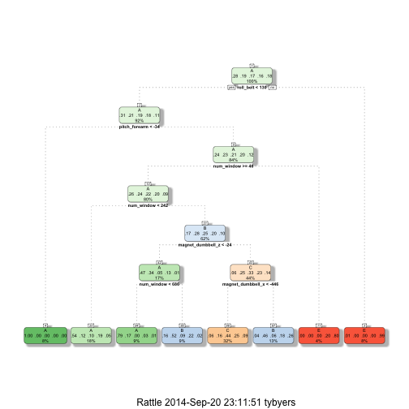

```r
fancyRpartPlot(rpmod$finalModel)
```

```r
rppred <- predict(rpmod, newdata = mytest)
confusionMatrix(rppred, mytest$classe)
```

```
## Confusion Matrix and Statistics
##
##           Reference
## Prediction    A    B    C    D    E
##          A 1169  188  106  190   52
##          B  106  521   90  192  158
##          C  115  240  659  383  134
##          D    0    0    0    0    0
##          E    5    0    0   39  557
##
## Overall Statistics
##
##                Accuracy : 0.593
##                  95% CI : (0.579, 0.606)
##     No Information Rate : 0.284
##     P-Value [Acc > NIR] : <2e-16
##
##                   Kappa : 0.479
##  Mcnemar's Test P-Value : <2e-16
##
## Statistics by Class:
##
##                      Class: A Class: B Class: C Class: D Class: E
## Sensitivity             0.838    0.549    0.771    0.000    0.618
## Specificity             0.847    0.862    0.785    1.000    0.989
## Pos Pred Value          0.686    0.488    0.430      NaN    0.927
## Neg Pred Value          0.929    0.888    0.942    0.836    0.920
## Prevalence              0.284    0.194    0.174    0.164    0.184
## Detection Rate          0.238    0.106    0.134    0.000    0.114
## Detection Prevalence    0.348    0.218    0.312    0.000    0.123
## Balanced Accuracy       0.843    0.705    0.778    0.500    0.804
```

The accuracy was only 0.5926 for the decision trees. I'll try a different model type.

## Random Forest Model

We prefer to use the `randomForest` package rather than call `rf` from within the `caret` package.

```r
library(randomForest)
rfmod <- randomForest(classe ~ ., data = mytrain)
importance(rfmod)
```

```
##                      MeanDecreaseGini
## user_name                      128.60
## num_window                    1023.68
## roll_belt                      853.03
## pitch_belt                     488.25
## yaw_belt                       605.30
## total_accel_belt               171.90
## gyros_belt_x                    68.40
## gyros_belt_y                    76.77
## gyros_belt_z                   218.07
## accel_belt_x                    83.96
## accel_belt_y                    88.11
## accel_belt_z                   273.09
## magnet_belt_x                  177.45
## magnet_belt_y                  270.88
## magnet_belt_z                  251.56
## roll_arm                       204.90
## pitch_arm                      113.61
## yaw_arm                        149.00
## total_accel_arm                 69.03
## gyros_arm_x                     74.28
## gyros_arm_y                     83.18
## gyros_arm_z                     36.81
## accel_arm_x                    176.11
## accel_arm_y                     95.14
## accel_arm_z                     84.91
## magnet_arm_x                   169.98
## magnet_arm_y                   140.74
## magnet_arm_z                   113.00
## roll_dumbbell                  294.04
## pitch_dumbbell                 123.96
## yaw_dumbbell                   174.66
## total_accel_dumbbell           190.89
## gyros_dumbbell_x                82.29
## gyros_dumbbell_y               151.48
## gyros_dumbbell_z                52.13
## accel_dumbbell_x               188.62
## accel_dumbbell_y               282.27
## accel_dumbbell_z               233.19
## magnet_dumbbell_x              366.01
## magnet_dumbbell_y              469.04
## magnet_dumbbell_z              521.20
## roll_forearm                   399.24
## pitch_forearm                  525.34
## yaw_forearm                    107.15
## total_accel_forearm             67.64
## gyros_forearm_x                 47.84
## gyros_forearm_y                 81.63
## gyros_forearm_z                 50.12
## accel_forearm_x                230.73
## accel_forearm_y                 90.03
## accel_forearm_z                157.28
## magnet_forearm_x               140.25
## magnet_forearm_y               139.00
## magnet_forearm_z               180.17
```

```r
rfpred <- predict(rfmod, newdata = mytest)
confusionMatrix(rfpred, mytest$classe)
```

```
## Confusion Matrix and Statistics
##
##           Reference
## Prediction    A    B    C    D    E
##          A 1394    0    0    0    0
##          B    0  948    4    0    0
##          C    0    1  851    6    0
##          D    0    0    0  798    0
##          E    1    0    0    0  901
##
## Overall Statistics
##
##                Accuracy : 0.998
##                  95% CI : (0.996, 0.999)
##     No Information Rate : 0.284
##     P-Value [Acc > NIR] : <2e-16
##
##                   Kappa : 0.997
##  Mcnemar's Test P-Value : NA
##
## Statistics by Class:
##
##                      Class: A Class: B Class: C Class: D Class: E
## Sensitivity             0.999    0.999    0.995    0.993    1.000
## Specificity             1.000    0.999    0.998    1.000    1.000
## Pos Pred Value          1.000    0.996    0.992    1.000    0.999
## Neg Pred Value          1.000    1.000    0.999    0.999    1.000
## Prevalence              0.284    0.194    0.174    0.164    0.184
## Detection Rate          0.284    0.193    0.174    0.163    0.184
## Detection Prevalence    0.284    0.194    0.175    0.163    0.184
## Balanced Accuracy       1.000    0.999    0.997    0.996    1.000
```

That was much better at 99.76% accuracy.

## Visualize Most Important Variables

We'll probably end up using a random forest for our final model. First though we'd like to plot the relationships between some variables that the random forest model found to be most important.

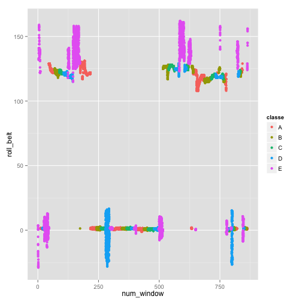

```r
ggplot(aes(x=num_window, y = roll_belt), data = mytrain) +
    geom_point(aes(color = classe))
```

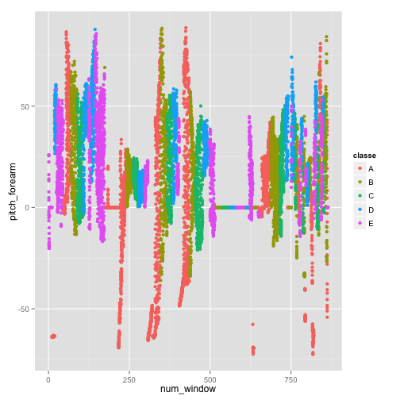

```r
ggplot(aes(x=num_window, y = pitch_forearm), data = mytrain) +
    geom_point(aes(color = classe))
```

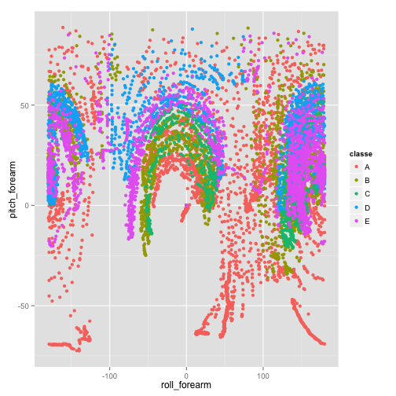

```r
ggplot(aes(x=roll_forearm, y = pitch_forearm), data = mytrain) +
    geom_point(aes(color = classe))
```

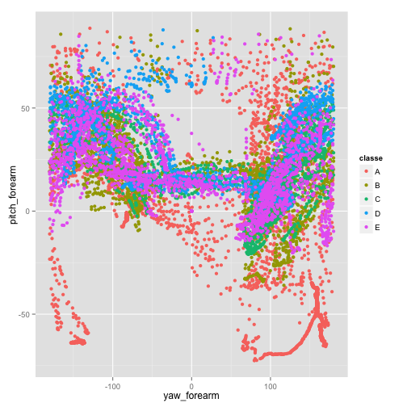

```r
ggplot(aes(x=yaw_forearm, y = pitch_forearm), data = mytrain) +
    geom_point(aes(color = classe))
```

Based on the above plots, it appears that the `classe` variable can be almost completely based on the num_window variable. That seems like cheating.

We'll investigate using another random forest model, running it with only num_window as the predictor.

```r
rfnwmod <- randomForest(classe ~ num_window, data = mytrain)
rfnwpred <- predict(rfnwmod, newdata = mytest)
confusionMatrix(rfnwpred, mytest$classe)
```

```
## Confusion Matrix and Statistics
##
##           Reference
## Prediction    A    B    C    D    E
##          A 1395    0    0    0    0
##          B    0  949    0    0    0
##          C    0    0  855    0    0
##          D    0    0    0  804    0
##          E    0    0    0    0  901
##
## Overall Statistics
##
##                Accuracy : 1
##                  95% CI : (0.999, 1)
##     No Information Rate : 0.284
##     P-Value [Acc > NIR] : <2e-16
##
##                   Kappa : 1
##  Mcnemar's Test P-Value : NA
##
## Statistics by Class:
##
##                      Class: A Class: B Class: C Class: D Class: E
## Sensitivity             1.000    1.000    1.000    1.000    1.000
## Specificity             1.000    1.000    1.000    1.000    1.000
## Pos Pred Value          1.000    1.000    1.000    1.000    1.000
## Neg Pred Value          1.000    1.000    1.000    1.000    1.000
## Prevalence              0.284    0.194    0.174    0.164    0.184
## Detection Rate          0.284    0.194    0.174    0.164    0.184
## Detection Prevalence    0.284    0.194    0.174    0.164    0.184
## Balanced Accuracy       1.000    1.000    1.000    1.000    1.000
```

And that was completely accurate. The question is, are the num_window vars the same in the test set? If so, we believe we've found a leak.

## Submit Test Set

I'm curious if I've found a leak (for more information on Leakage, see this Kaggle page: https://www.kaggle.com/wiki/Leakage). That is, if all the results are based on a single variable. I'm going to do a prediction on the main test set using the 1-variable prediction, and turn that in.

```r
rfnwpredall <- predict(rfnwmod, newdata = test)
rfnwpredall
```

```
##  1  2  3  4  5  6  7  8  9 10 11 12 13 14 15 16 17 18 19 20
##  B  A  B  A  A  E  D  B  A  A  B  C  B  A  E  E  A  B  B  B
## Levels: A B C D E
```

```r
pml_write_files = function(x){
  n = length(x)
  for(i in 1:n){
    filename = paste0("problem_id_",i,".txt")
    write.table(x[i],file=filename,quote=FALSE,row.names=FALSE,col.names=FALSE)
  }
}
pml_write_files(rfnwpredall)
```

That scored 20/20 on the submission page for the project. We think this definitely can be considered to be a leak.

With this very simple one-variable model (which we really consider as cheating!), we will likely have 100% out-of-sample error if new samples do not lie withi the `num_window` values we already have, but will have 0% out-of-sample errors if the new samples lie within our `num_window` values.

## Create New Model, Without Leak

We realize that finding the above variable may have given us 20/20 on the project submission page, but this is not at all a valid model to predict future data that may come in. So we're going to remove the offending variable from the training and testing sets.

```r
head(names(train))
```

```
## [1] "user_name"        "num_window"       "roll_belt"
## [4] "pitch_belt"       "yaw_belt"         "total_accel_belt"
```

```r
train <- train[,-2]
test <- test[,-2]
# Re-create mytrain and mytest sets
set.seed(919)
trainIndex <- createDataPartition(train$classe, p = 0.75, list = FALSE)
mytrain <- train[trainIndex,]
mytest <- train[-trainIndex,]
```

Now we re-create the random forest model to see how it does using everything else as predictors.

```r
rfmod <- randomForest(classe ~ ., data = mytrain)
importance(rfmod)
```

```
##                      MeanDecreaseGini
## user_name                      111.12
## roll_belt                      931.69
## pitch_belt                     504.95
## yaw_belt                       634.62
## total_accel_belt               162.39
## gyros_belt_x                    73.96
## gyros_belt_y                    86.74
## gyros_belt_z                   244.92
## accel_belt_x                    89.26
## accel_belt_y                    92.94
## accel_belt_z                   297.08
## magnet_belt_x                  185.25
## magnet_belt_y                  294.73
## magnet_belt_z                  297.53
## roll_arm                       225.30
## pitch_arm                      126.58
## yaw_arm                        186.33
## total_accel_arm                 79.31
## gyros_arm_x                     98.12
## gyros_arm_y                    103.07
## gyros_arm_z                     44.70
## accel_arm_x                    179.82
## accel_arm_y                    108.73
## accel_arm_z                     97.35
## magnet_arm_x                   181.66
## magnet_arm_y                   169.44
## magnet_arm_z                   144.73
## roll_dumbbell                  312.06
## pitch_dumbbell                 136.22
## yaw_dumbbell                   185.64
## total_accel_dumbbell           200.80
## gyros_dumbbell_x                99.36
## gyros_dumbbell_y               176.12
## gyros_dumbbell_z                63.18
## accel_dumbbell_x               182.55
## accel_dumbbell_y               305.75
## accel_dumbbell_z               256.68
## magnet_dumbbell_x              372.15
## magnet_dumbbell_y              509.55
## magnet_dumbbell_z              579.51
## roll_forearm                   444.78
## pitch_forearm                  575.06
## yaw_forearm                    132.41
## total_accel_forearm             82.88
## gyros_forearm_x                 53.61
## gyros_forearm_y                 89.80
## gyros_forearm_z                 63.75
## accel_forearm_x                233.60
## accel_forearm_y                106.78
## accel_forearm_z                182.14
## magnet_forearm_x               169.38
## magnet_forearm_y               163.10
## magnet_forearm_z               207.48
```

```r
rfpred <- predict(rfmod, newdata = mytest)
confusionMatrix(rfpred, mytest$classe)
```

```
## Confusion Matrix and Statistics
##
##           Reference
## Prediction    A    B    C    D    E
##          A 1394    2    0    0    0
##          B    0  946    9    0    0
##          C    0    1  845    9    2
##          D    0    0    1  795    0
##          E    1    0    0    0  899
##
## Overall Statistics
##
##                Accuracy : 0.995
##                  95% CI : (0.992, 0.997)
##     No Information Rate : 0.284
##     P-Value [Acc > NIR] : <2e-16
##
##                   Kappa : 0.994
##  Mcnemar's Test P-Value : NA
##
## Statistics by Class:
##
##                      Class: A Class: B Class: C Class: D Class: E
## Sensitivity             0.999    0.997    0.988    0.989    0.998
## Specificity             0.999    0.998    0.997    1.000    1.000
## Pos Pred Value          0.999    0.991    0.986    0.999    0.999
## Neg Pred Value          1.000    0.999    0.998    0.998    1.000
## Prevalence              0.284    0.194    0.174    0.164    0.184
## Detection Rate          0.284    0.193    0.172    0.162    0.183
## Detection Prevalence    0.285    0.195    0.175    0.162    0.184
## Balanced Accuracy       0.999    0.997    0.993    0.994    0.999
```

There are a few more errors than before, but we're still getting a very good 99.5% accuracy rate with the random forest.

## Cross-Validation

We feel fairly confident in this 99.5% accuracy rate. However, we will doing a 5-fold cross validation just to make sure.

```r
# create folds
set.seed(995)
folds <- createFolds(train$classe, k = 5)
str(folds)
```

```
## List of 5
##  $ Fold1: int [1:3923] 3 14 27 36 48 50 57 58 60 63 ...
##  $ Fold2: int [1:3923] 6 7 8 22 30 34 39 40 41 46 ...
##  $ Fold3: int [1:3925] 1 2 12 13 21 25 42 44 53 67 ...
##  $ Fold4: int [1:3926] 4 10 11 15 20 23 24 26 32 33 ...
##  $ Fold5: int [1:3925] 5 9 16 17 18 19 28 29 31 45 ...
```

```r
train01 <- train[-folds$Fold1,]
test01 <- train[folds$Fold1,]
train02 <- train[-folds$Fold2,]
test02 <- train[folds$Fold2,]
train03 <- train[-folds$Fold3,]
test03 <- train[folds$Fold3,]
train04 <- train[-folds$Fold4,]
test04 <- train[folds$Fold4,]
train05 <- train[-folds$Fold5,]
test05 <- train[folds$Fold5,]
```

Now we train a random forest on each of the training folds and predict on the corresponding test set.

```r
rfmod1 <- randomForest(classe ~ ., data = train01)
rfmod2 <- randomForest(classe ~ ., data = train02)
rfmod3 <- randomForest(classe ~ ., data = train03)
rfmod4 <- randomForest(classe ~ ., data = train04)
rfmod5 <- randomForest(classe ~ ., data = train05)
rfpred1 <- predict(rfmod1, newdata = test01)
rfpred2 <- predict(rfmod2, newdata = test02)
rfpred3 <- predict(rfmod3, newdata = test03)
rfpred4 <- predict(rfmod4, newdata = test04)
rfpred5 <- predict(rfmod5, newdata = test05)
cf1 <- confusionMatrix(rfpred1, test01$classe)
cf2 <- confusionMatrix(rfpred2, test02$classe)
cf3 <- confusionMatrix(rfpred3, test03$classe)
cf4 <- confusionMatrix(rfpred4, test04$classe)
cf5 <- confusionMatrix(rfpred5, test05$classe)
cf1$overall
```

```
##       Accuracy          Kappa  AccuracyLower  AccuracyUpper   AccuracyNull
##         0.9944         0.9929         0.9915         0.9965         0.2845
## AccuracyPValue  McnemarPValue
##         0.0000            NaN
```

```r
cf2$overall
```

```
##       Accuracy          Kappa  AccuracyLower  AccuracyUpper   AccuracyNull
##         0.9975         0.9968         0.9953         0.9988         0.2845
## AccuracyPValue  McnemarPValue
##         0.0000            NaN
```

```r
cf3$overall
```

```
##       Accuracy          Kappa  AccuracyLower  AccuracyUpper   AccuracyNull
##         0.9934         0.9916         0.9903         0.9957         0.2843
## AccuracyPValue  McnemarPValue
##         0.0000            NaN
```

```r
cf4$overall
```

```
##       Accuracy          Kappa  AccuracyLower  AccuracyUpper   AccuracyNull
##         0.9957         0.9945         0.9931         0.9975         0.2843
## AccuracyPValue  McnemarPValue
##         0.0000            NaN
```

```r
cf5$overall
```

```
##       Accuracy          Kappa  AccuracyLower  AccuracyUpper   AccuracyNull
##         0.9967         0.9958         0.9943         0.9982         0.2843
## AccuracyPValue  McnemarPValue
##         0.0000            NaN
```

```r
# average error:
(cf1$overall[1] + cf2$overall[1] + cf3$overall[1] + cf4$overall[1] +
     cf5$overall[1]) / 5
```

```
## Accuracy
##   0.9955
```

## Compare Recent Predictions with Absolute

Since I found the leak, I figured out all of the correct answers for the test set. However, let's see how well we do predicting this set with our 5 rf models created in the cross-validation above. So we are taking these five models, which use different parts of the training set, and “voting” for the correct classe.

```r
rfpred1final <- predict(rfmod1, newdata = test)
rfpred2final <- predict(rfmod2, newdata = test)
rfpred3final <- predict(rfmod3, newdata = test)
rfpred4final <- predict(rfmod4, newdata = test)
rfpred5final <- predict(rfmod5, newdata = test)
predfinal <- data.frame(rfpred1final, rfpred2final, rfpred3final,
                        rfpred4final, rfpred5final)
predfinal
```

```
##    rfpred1final rfpred2final rfpred3final rfpred4final rfpred5final
## 1             B            B            B            B            B
## 2             A            A            A            A            A
## 3             B            B            B            B            B
## 4             A            A            A            A            A
## 5             A            A            A            A            A
## 6             E            E            E            E            E
## 7             D            D            D            D            D
## 8             B            B            B            B            B
## 9             A            A            A            A            A
## 10            A            A            A            A            A
## 11            B            B            B            B            B
## 12            C            C            C            C            C
## 13            B            B            B            B            B
## 14            A            A            A            A            A
## 15            E            E            E            E            E
## 16            E            E            E            E            E
## 17            A            A            A            A            A
## 18            B            B            B            B            B
## 19            B            B            B            B            B
## 20            B            B            B            B            B
```

Looking at the above, we can see that all rows are identical for our prediction, so we don't even need to do a voting scheme – it's unanimous!

So we are guessing that this model also produces 100 percent accuracy on the test set; so we'll do a confusion matrix with the previous answers, which we know to be correct after turning them in.

```r
# arbitrary which rfpred?final vector we choose
confusionMatrix(predfinal$rfpred1final, rfnwpredall)
```

```
## Confusion Matrix and Statistics
##
##           Reference
## Prediction A B C D E
##          A 7 0 0 0 0
##          B 0 8 0 0 0
##          C 0 0 1 0 0
##          D 0 0 0 1 0
##          E 0 0 0 0 3
##
## Overall Statistics
##
##                Accuracy : 1
##                  95% CI : (0.832, 1)
##     No Information Rate : 0.4
##     P-Value [Acc > NIR] : 1.1e-08
##
##                   Kappa : 1
##  Mcnemar's Test P-Value : NA
##
## Statistics by Class:
##
##                      Class: A Class: B Class: C Class: D Class: E
## Sensitivity              1.00      1.0     1.00     1.00     1.00
## Specificity              1.00      1.0     1.00     1.00     1.00
## Pos Pred Value           1.00      1.0     1.00     1.00     1.00
## Neg Pred Value           1.00      1.0     1.00     1.00     1.00
## Prevalence               0.35      0.4     0.05     0.05     0.15
## Detection Rate           0.35      0.4     0.05     0.05     0.15
## Detection Prevalence     0.35      0.4     0.05     0.05     0.15
## Balanced Accuracy        1.00      1.0     1.00     1.00     1.00
```

As expected, we were 100% accurate, so it turns out we didn't need to have discovered the leak at all!